# Reparameterizing Bayesian state-space models for more reliable fits

## Objective

Translate nonlinear state-space model from BUGS to Stan and diagnose potential problems in the posterior.

Model from two papers:

- Meyer, Renate and Russell B. Millar. 1999. BUGs in Bayesian Stock assessments. *Canadian Journal of Fisheries and Aquatic Sciences*. 56:1078-1086.
- Millar, Russell B. and Renate Meyer. 2000. Non-linear state space modelling of fisheries biomass dynamics by using Metropolis-Hastings within-Gibbs sampling. *Applied Statistics*. 49, Part 3: 327-342.

## Model: Data

- \(C_t\): Catch biomass in year \(t\)
- \(I_t\): Catch per unit effort in year \(t\)

[figure not shown]

Albacore

## Model: Observation

\(I_t\) is an index of biomass \(B_t\). These are related through the parameter \(q\), catchability.

\[I_t = q B_t.\]

Nondimensionalizing \(B_t\) against carrying capacity \(K\) gives \(P_t = B_t / K\), observed with log-normal noise with CV \(\tau\).

\[\begin{aligned} I_t \mid P_t,q,\tau^2 &= q K P_t e^{v_t}\\ v_t &\sim \operatorname{Normal}(0, \tau^2). \end{aligned}\]

## Model: Population dynamics

- Schaefer dynamics
- Intrinsic growth rate \(r\)
- log-Normal noise with CV \(\sigma\)
- \(P_1\) near \(1\)

\[\begin{aligned} P_1 \mid \sigma^2 &= e^{u_1}\\ P_t \mid P_{t-1},K,r,\sigma^2 &= \left[ P_{t-1} + r P_{t-1}(1 - P_{t-1}) - \frac{C_{t-1}}{K} \right]e^{u_t}\\ u_t &\sim \operatorname{Normal}(0, \sigma^2), \end{aligned}\]

## Model: Priors

All but \(q\) at least somewhat informative, based on literature review. Specified \(\log(q) \sim \operatorname{Flat}\).

\[\begin{aligned} r &\sim \operatorname{log Normal}(-1.38, 0.51^2)\\ K &\sim \operatorname{log Normal}(5.04, 0.5162^2)\\ p(q) &\propto 1/q\\ \sigma^2 &\sim \operatorname{Inverse Gamma}(3.79, 0.0102)\\ \tau^2 &\sim \operatorname{Inverse Gamma}(1.71, 0.0086). \end{aligned}\]

## Model: BUGs Approximations

- Truncated priors
- Approximate \(p(q)\) with inverse-gamma.
- Problems in Stan

[figure not shown]

## Stan: No-U-Turn Sampler

- Hamiltonian dynamics
- Self-tuning

[NUTS Simulator](https://chi-feng.github.io/mcmc-demo/app.html#EfficientNUTS,banana)

- Divergences: too much curvature
- Max treedepth exceeded: too flat

## Stan: Changes

- Eliminate all truncations
- `lognormal` takes a standard deviation rather than a precision
- Use Inverse Gamma distribution
- Use specified prior on \(q\).

## Comparing model parameterizations

- Truncated: Original BUGs model fit in Stan
- Centered
- Noncentered log-Normal process errors
- Noncentered Normal process errors
- Marginalized \(q\)
- Additive error on catch
- Noncentered additive error on catch

## Noncentered log-Normal process errors

\[\begin{aligned} P_1 \mid \sigma^2 &= u_1 ^ \sigma\\ P_t \mid P_{t-1},\dots &= \bigg[ P_{t-1} + r P_{t-1}(1 - P_{t-1}) - \frac{C_{t-1}}{K} \bigg] u_t ^ \sigma\\ u_t &\sim \operatorname{log-Normal}(0, 1) \end{aligned}\]

## Noncentered Normal process errors

\[\begin{aligned} P_1 \mid \sigma^2 &= e^{u_1 \sigma}\\ P_t \mid P_{t-1},\dots &= \bigg[ P_{t-1} + r P_{t-1}(1 - P_{t-1}) - \frac{C_{t-1}}{K} \bigg] \exp(u_t \sigma)\\ u_t &\sim \operatorname{Normal}(0, 1) \end{aligned}\]

## Marginalized \(q\)

\[\begin{aligned} Z_i &= \log\left( \frac{I_i}{P_i K} \right)\\ \hat{q}' &= \frac{1}{n} \sum_i Z_i\\ Z_i &\sim \operatorname{Normal}(\hat{q}', \tau^2) \end{aligned}\]

From Walters & Ludwig (1994), *Calculation of Bayes posterior probability distributions for key populations parameters*.

## Noncentered additive error on catch

\[\begin{aligned} \nu &\sim \operatorname{Exponential}\left( \frac{\log(0.05)}{2.5} \right)\\ w_t &\sim \operatorname{Normal}(0, 1)\\ C^*_t &= C_t + w_t \nu\\ P_1 \mid \sigma^2 &= e^{u_1}\\ P_t \mid P_{t-1},\dots &= \bigg[ P_{t-1} + r P_{t-1}(1 - P_{t-1}) - \frac{C^*_{t-1}}{K} \bigg] \exp(u_t)\\ u_t &\sim \operatorname{Normal}(0, \sigma^2)\\ \end{aligned}\]

## Run specifications: full series

- \(4\) chains
- \(10,000\) iterations
- \(5,000\) warmup iterations
- \(20,000\) inference iterations

## Run specifications: shortened series

- \(4\) chains
- \(4,000\) iterations
- \(2,000\) warmup iterations
- \(8,000\) inference iterations

## Results: Full series diagnostics

|  | Treedepth | Treedepth Adj | Divergence | Divergence Adj |
| --- | --- | --- | --- | --- |
| Truncated | 0 |  | 6394 |  |
| Centered | 0 | 0 | 9 | 0 |
| Noncentered Lognormal | 0 | 52 | 233 | 0 |
| Noncentered Normal | 0 | 113 | 382 | 0 |
| Marginalized q | 0 | 0 | 1 | 0 |
| Explicit catch add | 0 | 0 | 41 | 11 |
| Exp catch nc add | 0 | 0 | 7 | 0 |

## Results: shortened series divergences

| Unadjusted | 6 | 12 | 18 | 23 |
| --- | --- | --- | --- | --- |
| Truncated | 6394 | 5492 | 5464 | 5690 |
| Centered | 9 | 17 | 8 | 8 |
| Noncentered Lognormal | 233 | 57 | 311 | 1997 |
| Noncentered Normal | 382 | 676 | 485 | 1558 |
| Marginalized q | 1 | 18 | 188 | 12 |
| Explicit Catch | 41 | 26 | 12 | 2 |
| Explicit Catch NC | 7 | 27 | 9 | 6 |

## Results: shortened series divergences

| Adjusted | 6 | 12 | 18 | 23 |
| --- | --- | --- | --- | --- |
| Centered | 0 | 1 | 0 | 0 |
| Noncentered Lognormal | 0 | 0 | 0 | 0 |
| Noncentered Normal | 0 | 0 | 1 | 0 |
| Marginalized q | 0 | 0 | 0 | 0 |
| Explicit Catch | 11 | 1 | 2 | 0 |
| Explicit Catch NC | 0 | 0 | 0 | 0 |

## Results: timing

|  | Warmup | Sampling | Min ESS Rate |
| --- | --- | --- | --- |
| Truncated | 20.3 | 26.4 | 13.7 |
| Centered | 15.9 | 19.7 | 147.0 |
| Noncentered log-Normal | 102.9 | 139.2 | 17.2 |
| Noncentered Normal | 101.2 | 80.5 | 32.3 |
| Marginalized q | 8.1 | 8.7 | 368.6 |
| Explicit Catch | 22.5 | 25.6 | 10.3 |
| Explicit Catch NC | 20.0 | 22.6 | 88.6 |

## Results: timing

|  | Warmup | Sampling | Min ESS Rate |
| --- | --- | --- | --- |
| Centered | 29.5 | 30.1 | 90.8 |
| Noncentered log-Normal | 227.0 | 197.5 | 13.8 |
| Noncentered Normal | 173.1 | 163.4 | 15.2 |
| Marginalized q | 15.5 | 14.6 | 189.2 |
| Explicit Catch | 64.2 | 89.4 | 1.8 |
| Explicit Catch NC | 37.8 | 37.3 | 60.7 |

## Results: \(w\)

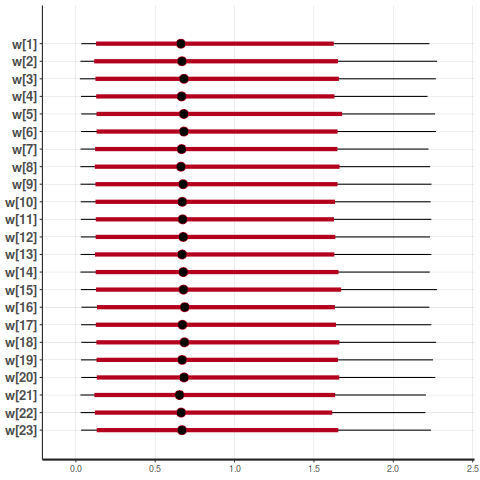

## Questions for you

- Other reparameterizations I should try?
- Different priors to use?
- Other ideas?